# Sprint 3 - Predicting Loan SubGrades

## 🚨 This is the continuation of the previous notebook. If this is the first file you are opening during correctiong, considering reviewing the readme file to understand how this project is structured

In the previous files:

- ✅ we have looked at our dataset: we have cleaned it and we have split our data into datasets for each of the sprints and tasks
- ✅ we have created a model that can predict loan elegibility
- ✅ we have created a model that can predict loan grade

In this file:

- we will create a model that can predict loan subgrade.

This notebook begins with the same boilerplate as the other ones (imports, basic feature toggles, etc...)

## Imports and initial setup

```python
import ipywidgets as widgets
from IPython.display import display, Markdown, Image, clear_output, HTML
import matplotlib.pyplot as plt
from matplotlib.patches import Rectangle
from itertools import groupby

import numpy as np
import pandas as pd
import seaborn as sns
from scipy import stats
from scipy.stats import chi2_contingency
import missingno as msno
import pygwalker as pyg
import pygwalker_utils.config as pyg_conf

import statsmodels.api as sm
import optuna

from random import random, seed
import sqlite3 as lite
import logging
import warnings
import ydata_profiling
import iplantuml
import xml.dom.minidom
from datetime import datetime, timedelta
import itertools
from os import path

from sklearn.feature_selection import SelectKBest, f_regression
from sklearn.metrics import (
    ConfusionMatrixDisplay,
    accuracy_score,
    recall_score,
    precision_score,
)
from sklearn.preprocessing import MinMaxScaler, StandardScaler, FunctionTransformer
from sklearn.impute import SimpleImputer
from sklearn.decomposition import PCA
from sklearn.linear_model import LinearRegression, LogisticRegression
from sklearn.model_selection import GridSearchCV
from sklearn.tree import plot_tree
from sklearn.metrics import (
    make_scorer,
    confusion_matrix,
    f1_score,
    PrecisionRecallDisplay,
)
from sklearn.pipeline import Pipeline
from sklearn.impute import KNNImputer
from sklearn.pipeline import make_pipeline
from sklearn.compose import ColumnTransformer
from sklearn.base import BaseEstimator, TransformerMixin
from sklearn.base import clone as clone_pipeline
from sklearn.metrics import classification_report

from sklearn.ensemble import RandomForestClassifier, ExtraTreesClassifier
from sklearn.linear_model import LogisticRegression
from xgboost import XGBClassifier
from sklearn.model_selection import GridSearchCV
from sklearn.svm import SVC
import shap
import yellowbrick
from yellowbrick.features import parallel_coordinates

from imblearn.under_sampling import RandomUnderSampler
import joblib
import pickle

import os
from os import path

from utils import *
from utils import __

from autofeat import AutoFeatRegressor as AFR
from sklearn.model_selection import train_test_split as sklearn_train_test_split
from sklearn.exceptions import DataConversionWarning

import category_encoders as ce

seed(100)
pd.options.display.max_rows = 100
pd.options.display.max_colwidth = 50
util.check("done")
```

```
INFO: Running in offline mode. There might be newer releases available. Please check at https://github.com/Kanaries/pygwalker or https://pypi.org/project/pygwalker.
INFO: Pandas backend loaded 1.5.3
INFO: Numpy backend loaded 1.23.5
INFO: Pyspark backend NOT loaded
INFO: Python backend loaded
```

```
loading utils modules... ✅ completed
configuring autoreload... ✅ completed
✅
```

```python
%reload_ext loans_clean
%reload_ext loans_utils
import loans_clean
from loans_utils import *
```

```python
from imblearn.under_sampling import RandomUnderSampler
```

Let's use `black` to auto-format all our cells so they adhere to PEP8

```python
import lab_black

%reload_ext lab_black
util.patch_nb_black()
# fmt: off
# fmt: on
```

```python
from sklearn import set_config

set_config(transform_output="pandas")
```

```python
logger = util.configure_logging(jupyterlab_level=logging.WARN, file_level=logging.DEBUG)

warnings.filterwarnings("ignore", category=FutureWarning)

# import warnings
# warnings.filterwarnings('error', category=pd.errors.DtypeWarning)
```

```python
def ding(title="Ding!", message="Task completed"):
    """
    this method only works on linux
    """
    for i in range(2):
        !notify-send '{title}' '{message}'
```

## Feature Toggles

Let's also create a simple feature toggle that we can use to skip expensive operations during notebook work (to save myself some time!)

Set it to true if you want to run absolutely everything. Set to false to skip optional steps/exploratory work.

```python
def run_entire_notebook():
    run_all = False
    if not run_all:
        print("skipping optional operation")
    return run_all
```

```python
def perform_split_once_off():
    split_files = False
    if not split_files:
        print("skipping once-off splitting operation")
    return split_files
```

# Machine Learning

For this iteration, we will not use the generated column we crafted (that was only needed for the first iteration).

Since the data cleaning and splitting are all done, this portion of the project (all the rest of them) will only require loading the right slice of data from disk!

This will be a lot more boring, so we will try to keep it light and focus on model performance instead of getting into detailed explanations. It's the same things we have done, with a bit more complexity (multiclass instead of binary classification)

```python
X_hyper = dataset_load(Sprint.subgrade, Phase.hyperparam, Dataset.X)
y_hyper = dataset_load(Sprint.subgrade, Phase.hyperparam, Dataset.y)
```

```python
X_train = dataset_load(Sprint.subgrade, Phase.train, Dataset.X)
y_train = dataset_load(Sprint.subgrade, Phase.train, Dataset.y)
```

## Checking class imbalance

We don't expect any good performance from any model that was intending to predict all 30+ classes, we don't even need to build it.

1. Too many classes
2. Up to 2 orders of magnitude between the most/least represented classes.

```
Loading from cache [./cached/charts/sprint3_class_balance_.png]
```

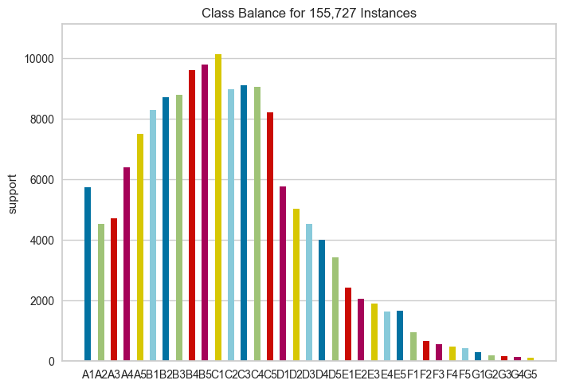

```python
@run
@cached_chart()
def sprint3_class_balance_():
    ax = plt.gca()
    yellowbrick.target.class_balance(y_hyper, ax=ax)
    return ax
```

## Visualizing attributes using yellowbrick

We also don't need this to know that this dataset has too much complexity to attempt to predict subgrade using a single model

```
Loading from cache [./cached/charts/sprint3_parallel_coordinates.png]
```

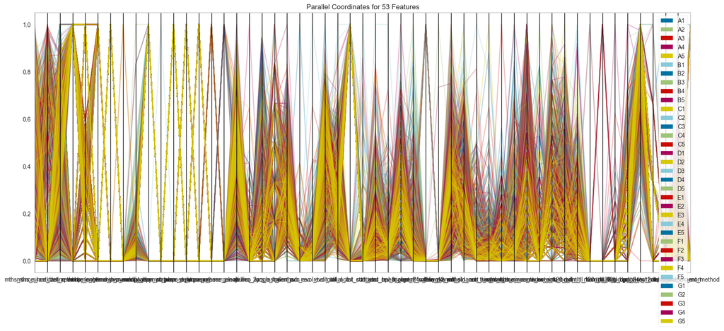

```python
@run
@cached_chart()
def sprint3_parallel_coordinates():
    smallest_class = y_hyper.value_counts().min()
    rus = RandomUnderSampler(
        sampling_strategy={
            "C1": smallest_class,
            "B5": smallest_class,
            "B4": smallest_class,
            "C3": smallest_class,
            "C4": smallest_class,
            "C2": smallest_class,
            "B3": smallest_class,
            "B2": smallest_class,
            "B1": smallest_class,
            "C5": smallest_class,
            "A5": smallest_class,
            "A4": smallest_class,
            "D1": smallest_class,
            "A1": smallest_class,
            "D2": smallest_class,
            "A3": smallest_class,
            "D3": smallest_class,
            "A2": smallest_class,
            "D4": smallest_class,
            "D5": smallest_class,
            "E1": smallest_class,
            "E2": smallest_class,
            "E3": smallest_class,
            "E5": smallest_class,
            "E4": smallest_class,
            "F1": smallest_class,
            "F2": smallest_class,
            "F3": smallest_class,
            "F4": smallest_class,
            "F5": smallest_class,
            "G1": smallest_class,
            "G2": smallest_class,
            "G3": smallest_class,
            "G4": smallest_class,
            "G5": smallest_class,
        },
        random_state=42,
    )
    X_hyper_resampled, y_hyper_resampled = rus.fit_resample(X_hyper, y_hyper)
    X_hyper_scaled = MinMaxScaler().fit_transform(X_hyper_resampled)
    plt.figure(figsize=(20, 8))
    ax = plt.gca()
    parallel_coordinates(X_hyper_scaled, y_hyper_resampled, ax=ax)
    return ax
```

This chart crosses the boundaries between "Data Science" and into "Data Modern Art"...

I shall expose it at a snob art gallery and become rich!

We don't need to read the labels to see that the patterns in this dataset are going to be hard to separate by most models

## Creating smaller models to predict subgrades

We will create subsets for each of the grades, and we will apply the "1-model-per-subset" pattern, which, we hope will be somewhat meaningful and accurate.

The target columns are "A1, B2, B3,... " and we could be tempted to use the last digit only, and to treat them as numeric instead of categorical, but we need to remember that we shouldn't! Because, while we can assume that A2 will always be between A1 and A3, we must remember that the distance between "A1" and "A2" might not be the same as between "A2" and "A3"... and thus, trying to use regression for this, could not provide the results we expected.

So we will treat them as a **classificaton** problem instead of a regression problem

```python
X_hyper["grade"] = y_hyper.str.get(0)
grouped_grades = X_hyper.groupby("grade")
```

```python
X_train["grade"] = y_train.str.get(0)
grouped_grades_train = X_train.groupby("grade")
```

```
Loading from cache [./cached/charts/sprint3_class_balance_grades.png]
```

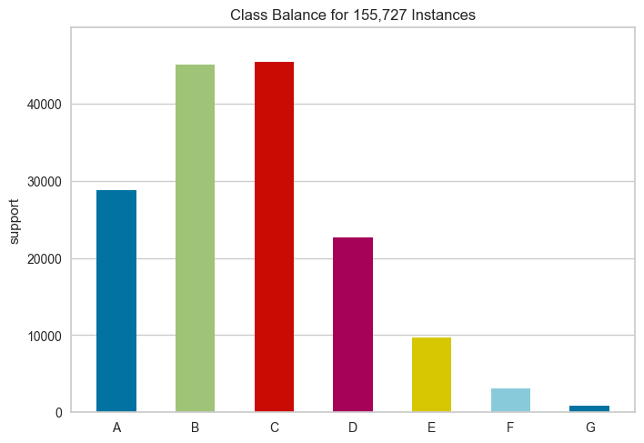

```python
@run
@cached_chart()
def sprint3_class_balance_grades():
    ax = plt.gca()
    yellowbrick.target.class_balance(X_hyper["grade"], ax=ax)
    return ax
```

We can see that the this dataset follows the same overall distribution that the previous one had (obviously).

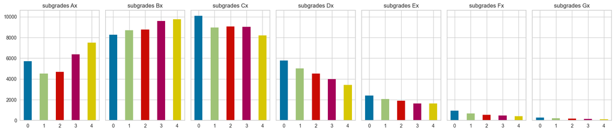

```python
grades = ["A", "B", "C", "D", "E", "F", "G"]
fig, axs = plt.subplots(1, 7, figsize=(18, 4), sharey=True)
for i, grade in enumerate(grades):
    cax = axs[i]
    visualizer = yellowbrick.classifier.ClassBalance(ax=cax)
    visualizer.fit(y_hyper.loc[grouped_grades.get_group(grade).index])
    cax.set_title(f"subgrades {grade}x")

plt.tight_layout()
```

It seems that the datasets are more balanced if we look inside each of the main grades. This is promising.

## Training models, in bulk

Let's train the same models that worked well on sprint 2, but for each of the folds in our dataset:

```python
grades = [
    "A",
    "B",
    "C",
    "D",
    "E",
    "F",
    "G",
]
```

```python
candidate_providers = {
    "xgbclassifier": optuna_utils.XgbClassifierCandidateProvider(),
    "logreg": optuna_utils.LogisticRegressionCandidateProvider(),
    "extra_trees": optuna_utils.ExtRaTreesCandidateProvider(),
    "random_forest": optuna_utils.RandomForestCandidateProvider(),
}
```

```python
def f1_score_macro(*args, **kwargs):
    # we will use macro, since all of these datasets are unbalanced.
    # https://stephenallwright.com/micro-vs-macro-f1-score/
    score = f1_score(*args, **kwargs, average="macro")
    return score


def tune_all_models():
    # let's do it in reverse order
    for grade in reversed(grades):
        X = grouped_grades.get_group(grade).drop(columns="grade")
        y = y_hyper.loc[X.index]
        print(f"Creating model for {grade}", "-", X.shape)

        for model_name, candidate_provider in candidate_providers.items():
            print("training model:", model_name, "for", grade)
            study_name = f"sprint3_attempt2_{model_name}_subgrade_{grade}"
            optuna_utils.create_optuna_study(
                study_name=study_name, allow_resume=True, direction="maximize"
            )
            objective = optuna_utils.build_objective_function(
                candidate_provider, X, y, scoring_function=f1_score_macro
            )
            optuna_utils.parallelize_optuna(
                study_name, n_processes=10, trials_per_process=2, objective=objective
            )


if run_entire_notebook():
    tune_all_models()
```

```
skipping optional operation
```

# Understanding our model's training and performance

One of the benefits of Optuna is that the studies and trials are persisted forever, and we can analyze them even further (meta analysis, here we come!)

Specifically, we want to see:

- how they performed
- how long they took
- how our strategy changed after +10h of tuning models
- and which models were most/least optimal for this specific dataset

```python
grades = [
    "A",
    "B",
    "C",
    "D",
    "E",
    "F",
    "G",
]

candidates = ["xgbclassifier", "logreg", "extra_trees", "random_forest"]
```

```python
subgrade_studies = {}
for candidate, grade in itertools.product(candidates, grades):
    study_name = f"sprint3_{candidate}_subgrade_{grade}"
    filename = f"optuna_studies/study_{study_name}.db"
    if path.exists(filename):
        print(filename, "ok ✅")
        subgrade_studies[study_name] = optuna_utils.get_study(study_name=study_name)
    else:
        print(filename, "skipping...")
```

```
optuna_studies/study_sprint3_xgbclassifier_subgrade_A.db ok ✅
optuna_studies/study_sprint3_xgbclassifier_subgrade_B.db ok ✅
optuna_studies/study_sprint3_xgbclassifier_subgrade_C.db ok ✅
optuna_studies/study_sprint3_xgbclassifier_subgrade_D.db ok ✅
optuna_studies/study_sprint3_xgbclassifier_subgrade_E.db ok ✅
optuna_studies/study_sprint3_xgbclassifier_subgrade_F.db ok ✅
optuna_studies/study_sprint3_xgbclassifier_subgrade_G.db ok ✅
optuna_studies/study_sprint3_logreg_subgrade_A.db ok ✅
optuna_studies/study_sprint3_logreg_subgrade_B.db ok ✅
optuna_studies/study_sprint3_logreg_subgrade_C.db ok ✅
optuna_studies/study_sprint3_logreg_subgrade_D.db ok ✅
optuna_studies/study_sprint3_logreg_subgrade_E.db ok ✅
optuna_studies/study_sprint3_logreg_subgrade_F.db ok ✅
optuna_studies/study_sprint3_logreg_subgrade_G.db ok ✅
optuna_studies/study_sprint3_extra_trees_subgrade_A.db ok ✅
optuna_studies/study_sprint3_extra_trees_subgrade_B.db ok ✅
optuna_studies/study_sprint3_extra_trees_subgrade_C.db ok ✅
optuna_studies/study_sprint3_extra_trees_subgrade_D.db ok ✅
optuna_studies/study_sprint3_extra_trees_subgrade_E.db ok ✅
optuna_studies/study_sprint3_extra_trees_subgrade_F.db ok ✅
optuna_studies/study_sprint3_extra_trees_subgrade_G.db ok ✅
optuna_studies/study_sprint3_random_forest_subgrade_A.db ok ✅
optuna_studies/study_sprint3_random_forest_subgrade_B.db ok ✅
optuna_studies/study_sprint3_random_forest_subgrade_C.db ok ✅
optuna_studies/study_sprint3_random_forest_subgrade_D.db ok ✅
optuna_studies/study_sprint3_random_forest_subgrade_E.db ok ✅
optuna_studies/study_sprint3_random_forest_subgrade_F.db ok ✅
optuna_studies/study_sprint3_random_forest_subgrade_G.db ok ✅
```

## Understanding tuning duration

```python
def as_minutes(duration):
    minutes = duration.total_seconds() / 60
    return minutes
```

```python
def get_study_type(candidate, grade):
    FULL = ("full  (15 cpus x 5 loops)", "green")
    KILLED = ("manually stopped", "red")
    SHORT = ("short (10 cpu x loops)", "orange")
    if grade in ["E", "F", "G"]:
        return FULL
    elif grade == "D":
        if candidate == "xgbclassifier":
            return FULL
        elif candidate == "logreg":
            return KILLED
        else:
            return SHORT
    else:
        return SHORT
```

```
Loading from cache [./cached/charts/sprint3_all_optuna_models.png]
```

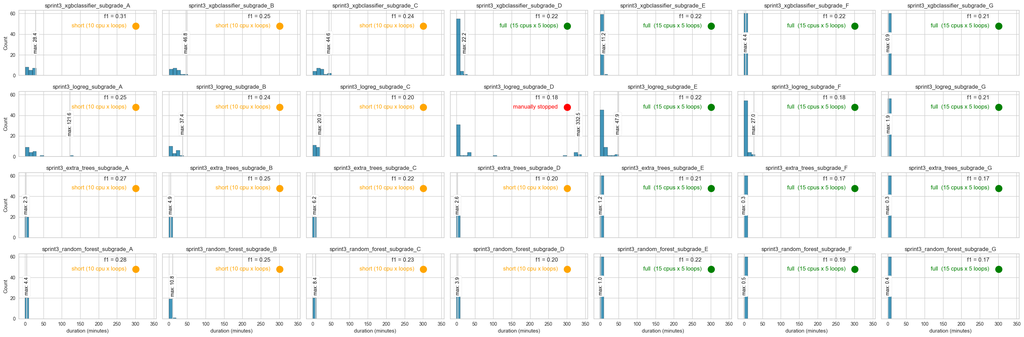

```python
@run
@cached_chart()
def sprint3_all_optuna_models():
    f, ax = plt.subplots(4, 7, figsize=(30, 10), sharex=True, sharey=True)

    for (c, candidate), (g, grade) in itertools.product(
        enumerate(candidates), enumerate(grades)
    ):
        cax = ax[c, g]
        study_name = f"sprint3_{candidate}_subgrade_{grade}"
        if not study_name in subgrade_studies:
            continue
        study_type, color = get_study_type(candidate, grade)
        study = subgrade_studies[study_name]
        df = study.trials_dataframe()
        durations = df["duration"].apply(as_minutes)

        cax.set_title(study_name)
        sns.histplot(durations, ax=cax, binwidth=10)
        cax.plot(
            0.85, 0.76, transform=cax.transAxes, marker="o", markersize=15, color=color
        )
        score_label = f"f1 = {study.best_value:.2f}"
        cax.annotate(
            score_label,
            xy=(0.8, 0.9),
            xycoords="axes fraction",
            xytext=(-5, -5),
            textcoords="offset points",
            ha="right",
            va="bottom",
        )
        cax.annotate(
            study_type,
            xy=(0.8, 0.8),
            xycoords="axes fraction",
            xytext=(-5, -5),
            textcoords="offset points",
            color=color,
            ha="right",
            va="center",
        )
        cax.set_xlabel("duration (minutes)")
        chart_utils.line(
            x=durations.max(),
            ax=cax,
            label_format=".1f",
            label_prefix="max",
            label_pos=0.5,
        )

    plt.tight_layout()
    return f
```

## Knowing when to stop

The performance of these models is so poor that it doesn't make sense to even try to assess performance on unseen data.

```
Loading from cache [./cached/charts/sprint3_all_confusion_matrices_unseen_data.png]
```

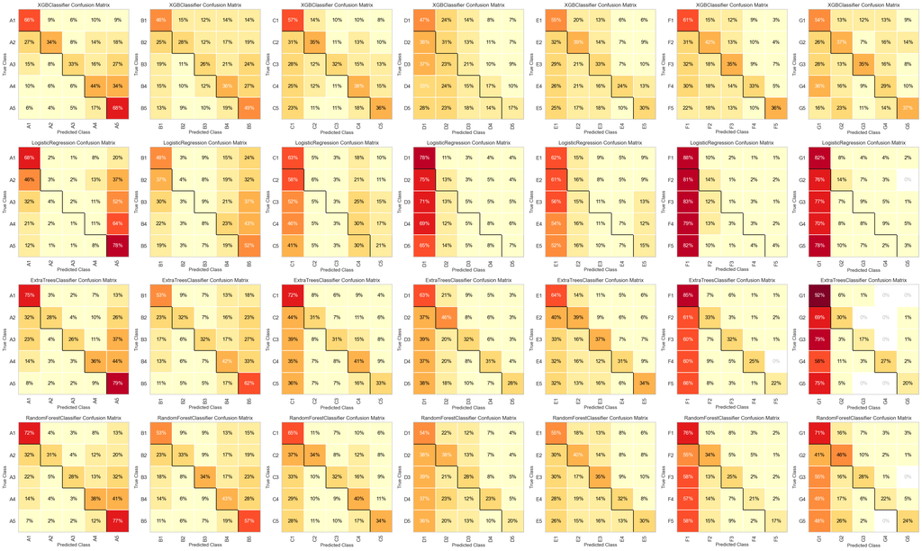

```python
@cached_chart(force=False)
def sprint3_all_confusion_matrices_unseen_data():
    fig, ax = plt.subplots(4, 7, figsize=(30, 18))

    for (c, candidate), (g, grade) in itertools.product(
        enumerate(candidates), enumerate(grades)
    ):
        cax = ax[c, g]
        study_name = f"sprint3_{candidate}_subgrade_{grade}"
        filename = f"cached/pickle/conf_matrix_{study_name}.pkl"
        print(f"starting model {study_name}")

        X = grouped_grades_train.get_group(grade).drop(columns="grade").sample(frac=0.3)
        y = y_train.loc[X.index]

        (
            X_train_split,
            X_test_split,
            y_train_split,
            y_test_split,
        ) = sklearn_train_test_split(X, y, test_size=0.2, random_state=42, stratify=y)

        if path.exists(filename):
            with open(filename, "rb") as f:
                best_model = pickle.load(f)
        else:
            best_model = optuna_utils.get_best_model(study_name)

            # see notes in markdown above!
            print(f"fitting {study_name}")
            best_model.fit(X_train_split, y_train_split)
            print("done")
            with open(filename, "wb") as f:
                pickle.dump(best_model, f)

        cm = yellowbrick.classifier.ConfusionMatrix(
            best_model, is_fitted=True, ax=cax, percent=True
        )
        cm.fit(X_train_split, y_train_split)
        cm.score(X_test_split, y_test_split)
        cm.finalize()

    plt.tight_layout()
    return fig


sprint3_all_confusion_matrices_unseen_data()
```

Let's also check the absolute values.

Remember that the colours on the chart below are different due to how heatmaps work (they build a scale across the entire range of numbers instead of creating a new scale per row) . If you want to use colours to quickly find hotspots, use the chart above only.

```
Loading from cache [./cached/charts/sprint3_all_confusion_matrices_unseen_data_absolute_counts.png]
```

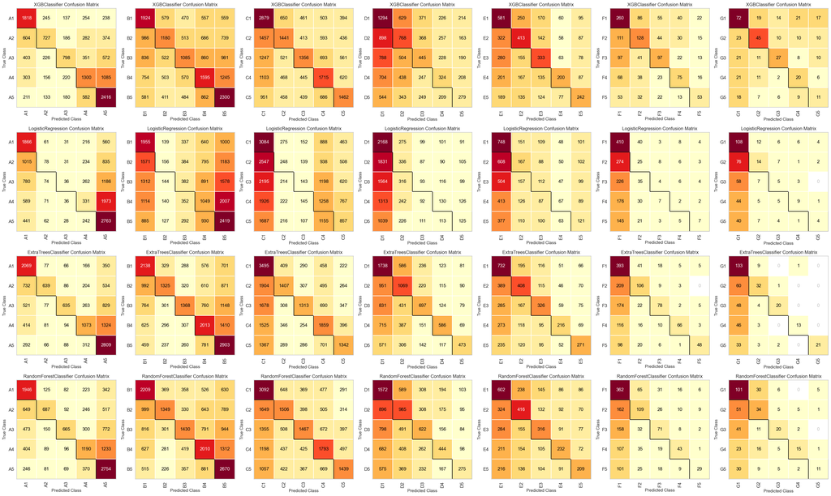

```python
@run
@cached_chart(force=False)
def sprint3_all_confusion_matrices_unseen_data_absolute_counts():
    raise ValueError(
        "Do not rerun this. "
        "This is just to re-render another version of "
        "the chart above using absolute values"
    )
```

## Some thoughts on the models used

Reminder: This is only using a subset of the data! (see `.sample(frac=0.xx)`) above

In the end, in order to be able to create a single giant set of charts, I had to use less data than ideal

The data required for this confusion matrix is quite big: I am not including it in this project's repo.

If you'd like to recreate it from scratch, go fot it :)

If you'd like to save some time, I will try to store a pre-rendered version of it as an image

models trained on 10% of the data = 4GB models trained on 30% of the data = ??GB models trained on 50% of the data = 11GB

[figure not shown]

Some additional thoughts:

- training xgb is a lot easier than other models (logreg!). the memory usage is a lot more stable and not highly increasing/decreasing.
- logreg is tiny on disk, so it's easy to move around, but it's a nightmare to train.
- there is something weird going on between class B and class C on random forests... the dataset is almost identical in size, but the trained model is SO much smaller for class C. This is consistent across all the different runs (10% sample, 30% sample, 50% sample, etc..)
- Maybe I am being biased, maybe it's experience, but I am slowly moving away from logreg. The primary instinct is that I don't think of it as a tool with benefits, anymore... which is sort of sad.
  - I think I need to think of it as "the right tool, but not for this job" (large dataset, highly dimensional, not easily fittable by a logreg algorithm), instead of blaming the specific algorithm or the resulting model.
  - This will require willpower and use of rational thinking instead of allowing these bad experiences from biasing the rest of my professional career

### Reflecting on the Optuna Framework and how to use it better in the future

I think that next time I have a bunch of models to check, I should change the way I manage my compute resources, so they allow optuna to reach better results.

So... What happened?

I launched the hyperparameter tuning last night before going to bed, and I set it to run backwards (from the smallest dataset to the largest), just in case there were memory limitations that made the entire process crash (fortunately, nothing crashed)!

While I was sleeping, optuna ran all the "full" searches on the smaller datasets: G, F, E, and part of D.

This morning, I woke up to find that it was still running on dataset D for logistic regression, and that most of the *non-immediately pruned runs* were taking +5h.

This, however, is far from ideal, because, as far as I can tell, Optuna tries to iteratively improve, which means that it would be much better to have a different configuration (2 processes x 12 runs), but that would defeat the purpose of the multiprocessing (= being able to utilize the CPU cores fully).

The optimal strategy would be to allow optuna to slowly iterate over the search space over multiple iterations.

So instead of doing concurrency like this (current model):

[figure not shown]

It might be better to do it like this, as it would allow more iterative improvements.

[figure not shown]

* *yes, I know that processes don't run so perfectly sequentially within the same cpu core, consider the numbers representing "iterations" simply an approximation to an ideal state*

If I ever need to run such a large variations of models, I will considering restructuring my code to allow this.

## Understanding optimization performance

There is a clear loser among the 4 algorithms we chose (in the context of *this* dataset):

It seems that LogisticRegression struggles consistently with this dataset:

- it consistently gets the lowers performance of all 4 models, in **most** of the grades
- it consistently takes orders of magnitude longer to find the "best" hyperparameters
- after inspections of the logs, lots of the completed trials also failed to converge

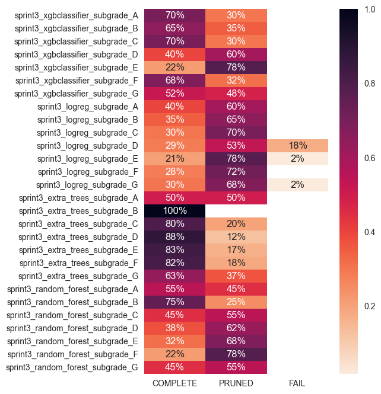

```python
def count_by_state(studies):
    data = []
    study_names = []
    for study in studies:
        trials = study.trials
        trials_states = [trial.state for trial in trials]
        counts = {state: trials_states.count(state) for state in set(trials_states)}
        data.append(counts)
        study_names.append(study.study_name)

    df = pd.DataFrame(data, index=study_names)
    df.columns = df.columns.map(lambda x: optuna.trial.TrialState(x).name)
    df_percent = df.div(df.fillna(0).sum(axis=1), axis=0)
    return df_percent


plt.figure(figsize=(5, 8))
sns.heatmap(
    count_by_state(subgrade_studies.values()), cmap="rocket_r", annot=True, fmt=".0%"
)
```

A few things to highlight:

Considering how poor the performance is on all of these varied models, we understand that this would be a difficult task to optimize and that trying to tune these in a professional environment would require far more time than what we have available for such a simple project. Things including tuning the dataset, getting a better understanding of the domain, getting assistance from experts in the field who would help us understand the data, the relations, and the intricacies that all of these fields hide, selecting optimal algorithms that might have worked in similar datasets in the past, and THEN, and only then, getting into tuning hyperparameter and performance.

Due to the excessive amount of work/dev-time/cpu-time this would require, we consider these tasks as future improvements, and we will leave them as out of scope for this project.

# Next steps

This is the end of sprint 3.

In this sprint, we have have built models to predict the loan subgrade using algorithms that support multiclass single-label outputs.

Given how many labels there were, we decided to try to model multiple simple models instead of one giant model.

Despite these efforts, the performance is still suboptimal. We have also meta-analyzed our optimization tasks to see how optuna works under the hood to report tuning performacne. We will cover more of these lessons learned at the end of the project.

We are ready to jump into the next step: making a model to predict the loan's interest rate.

Jump into the notebook for sprint4, whenever you are ready.